# MonthlyAnalysis

```r
library(tswge)
library(readr)
library(dplyr)
library(tidyr)
library(lubridate)
```

### 1) Prepare Data.

I’m changing the dataset to be a monthly data.

```r
#Load original Kaggle Data
saas <- read_csv("SaaS-Sales.csv")

#Get only relevant columns. Then get total sum of sales made for each day.
##  Data only has dates for which sales were made
amazon = saas %>%
  mutate(
    orderdate = mdy(`Order Date`),
    year = year(orderdate),
    quarter = paste0("Qtr", quarter(orderdate)),
    month = month(orderdate, label = TRUE, abbr = TRUE)
  ) %>%
  group_by(year, quarter, month, orderdate) %>%
  summarise(
    sumofsales = sum(Sales, na.rm = TRUE),
    .groups = "drop"
  ) %>%
  arrange(orderdate)
```

```r
amazon_monthly <- amazon %>%
  mutate(
    orderdate = (orderdate),
    orderdate = make_date(year(orderdate), month(orderdate), 1),
    month_num = month(orderdate),
    month_label = paste0(
      sprintf("%02d", month_num),
      "-",
      month(orderdate, label = TRUE, abbr = TRUE)
    )
  ) %>%
  group_by(year, quarter, month, month_num, month_label, orderdate) %>%
  summarise(
    monthly_sales = sum(sumofsales, na.rm = TRUE),
    .groups = "drop"
  )
```

### 2) Visually inspect the data

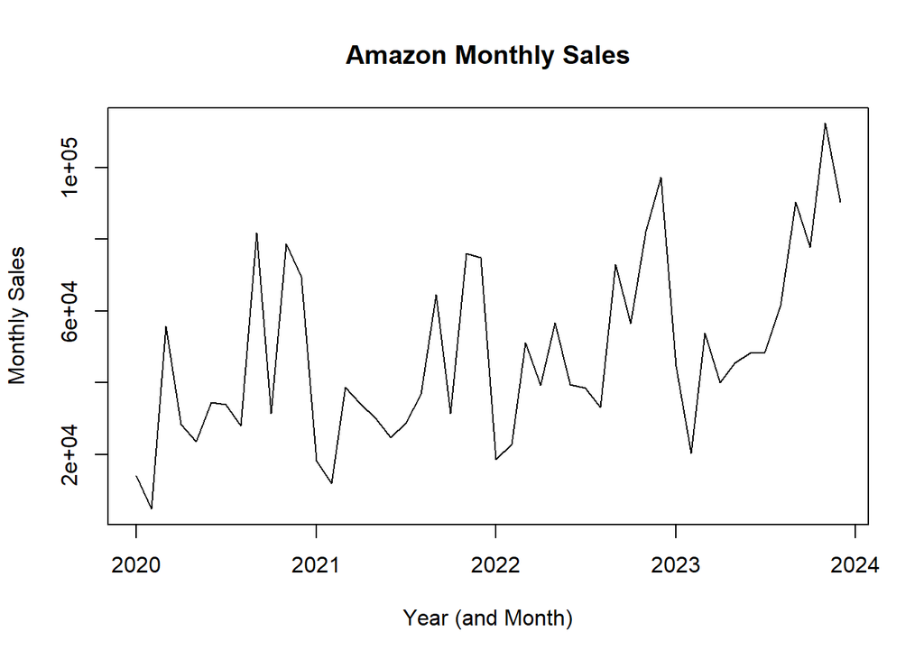

```r
amazon_monthly <- amazon_monthly[order(amazon_monthly$orderdate), ]

plot(
  amazon_monthly$orderdate,
  amazon_monthly$monthly_sales,
  type = "l",
  xlab = "Year (and Month)",
  ylab = "Monthly Sales",
  main = "Amazon Monthly Sales"
)
```

### 3) Convert the amazon_monthly to a time series type file

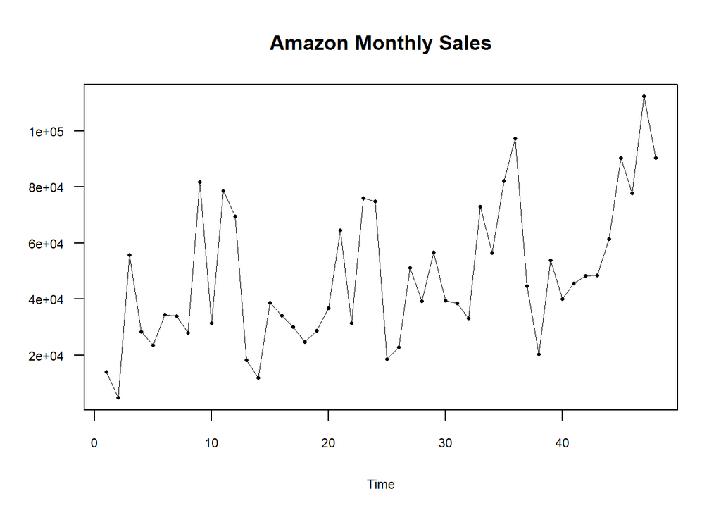

```r
amazon_ts = ts(amazon_monthly$monthly_sales,start=c(2020,1),end=c(2023,12),frequency = 12)

#plot(amazon_ts)
 plotts.wge(amazon_ts, main="Amazon Monthly Sales")
```

### 4) Use plotts to observe autocorrelations and spectral frequency

The realization here looks seasonal, with a period of 12. There appears to be an increasing trend, but it is not clearly obvious from the appearance in the realization. The autocorrelation shows some decay, but there are some prominent spikes in the lag of 0, lag=12 and lag=24.

The Spectral frequency shows peaks near 0, possibly near 0.08 and 0.33. This corresponds with a period of almost infinity, but also approximately 12 and 3.

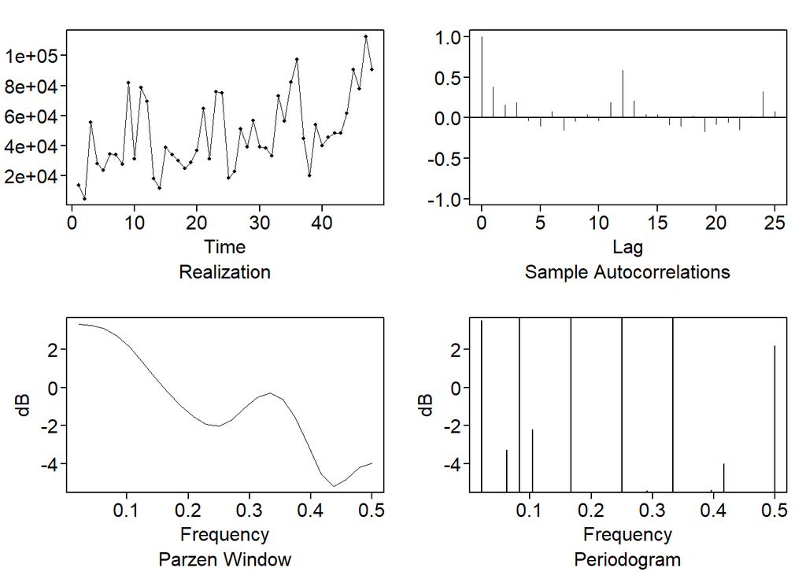

```r
# I include periodogram, otherwise 3 charts side by side looks cramped
sp=plotts.sample.wge(amazon_ts,periodogram=TRUE)
```

Any difference when you log the data. (NO)

I tried to log the dataset, but the changes to see anything is minimal here.

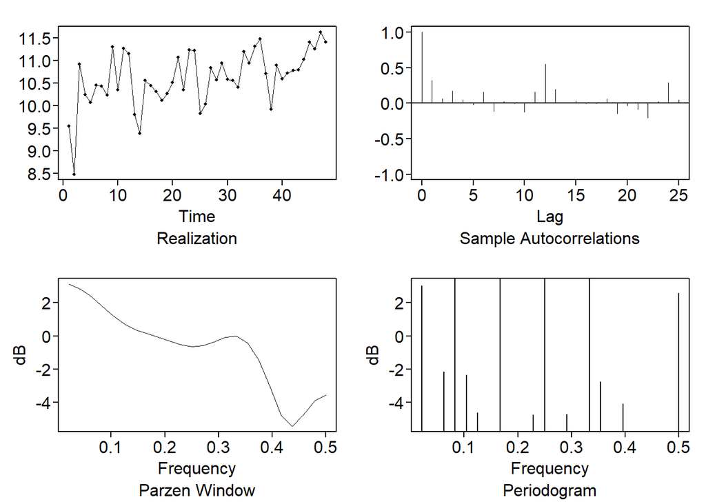

```r
amazon_ts_log = log(amazon_ts)

sp=plotts.sample.wge(amazon_ts_log,periodogram=TRUE)
```

### 5) Check for white noise using ljung-box test.

Try K=12, to match the period in the data, corresponding to 1 year.

```r
ljung.wge(amazon_ts, K = 12)
```

```
Obs 0.3782248 0.1578444 0.1894325 -0.03339628 -0.09671621 0.07997101 -0.1537882 -0.03779415 0.04354166 -0.03405579 0.1872269 0.5869266
```

```
$test
[1] "Ljung-Box test"

$K
[1] 12

$chi.square
[1] 38.36637

$df
[1] 12

$pval
[1] 0.0001337516
```

Try K=24, to correspond with 2 years (24 months)

```r
# K = 24 checks the first two years of monthly autocorrelations.
ljung.wge(amazon_ts, K = 24)
```

```
Obs 0.3782248 0.1578444 0.1894325 -0.03339628 -0.09671621 0.07997101 -0.1537882 -0.03779415 0.04354166 -0.03405579 0.1872269 0.5869266 0.2082642 0.03789653 0.04292033 -0.08272336 -0.09777563 0.02599054 -0.1650921 -0.0797545 -0.05364799 -0.146857 0.0148252 0.3250674
```

```
$test
[1] "Ljung-Box test"

$K
[1] 24

$chi.square
[1] 58.51878

$df
[1] 24

$pval
[1] 0.0001030702
```

The Ljung-Box test rejects the null hypothesis of white noise for the raw monthly sales series at K = 12 and K = 24. This indicates that the raw series contains statistically significant autocorrelation. Since the time plot also showed large sales spikes and possible changes in level, I tested this data against other models, such as ARMA, AR, and line series.

### 6) Identifying p, q values.

```r
aic.wge(amazon_ts,p= 0:10,q= 0:6) #AIC selects p= 6,q= 4
```

```
$type
[1] "aic"

$value
[1] 19.89995

$p
[1] 6

$q
[1] 4

$phi
[1] -0.3413129  0.4093278  0.7107248  0.2701342 -0.4420216  0.2477435

$theta
[1] -1.0720336 -0.2273615  0.7335367  0.8781522

$xbar
[1] 47858.35

$vara
[1] 277578387
```

```r
aic.wge(amazon_ts,p= 0:10,q= 0:6,type= 'bic') #BIC selects p= 1,q= 0
```

```
$type
[1] "bic"

$value
[1] 20.22039

$p
[1] 1

$q
[1] 0

$phi
[1] 0.4108144

$theta
[1] 0

$xbar
[1] 47858.35

$vara
[1] 514696777
```

### 7) Try to fit ARMA process.

```r
amazon_arma64_fit =  est.arma.wge(amazon_ts, p = 6, q = 4)
```

```
Coefficients of AR polynomial:
-0.3413 0.4093 0.7107 0.2701 -0.4420 0.2477

                           AR Factor Table
Factor                 Roots                Abs Recip    System Freq
1+1.0000B             -1.0000               1.0000       0.5000
1+1.0124B+0.9975B^2   -0.5075+-0.8631i      0.9988       0.3346
1-0.9556B              1.0464               0.9556       0.0000
1-0.7154B+0.2599B^2    1.3764+-1.3976i      0.5098       0.1262




Coefficients of MA polynomial:
-1.0720 -0.2274 0.7335 0.8782

                              MA FACTOR TABLE
Factor                 Roots                Abs Recip    System Freq
1+0.9610B+0.9994B^2   -0.4808+-0.8772i      0.9997       0.3298
1+0.9945B             -1.0055               0.9945       0.5000
1-0.8835B              1.1318               0.8835       0.0000
```

Check Stationary and invertibility?

```r
factor.wge(phi = amazon_arma64_fit$phi)
```

```
Coefficients of AR polynomial:
-0.3413 0.4093 0.7107 0.2701 -0.4420 0.2477

                           AR Factor Table
Factor                 Roots                Abs Recip    System Freq
1+1.0000B             -1.0000               1.0000       0.5000
1+1.0124B+0.9975B^2   -0.5075+-0.8631i      0.9988       0.3346
1-0.9556B              1.0464               0.9556       0.0000
1-0.7154B+0.2599B^2    1.3764+-1.3976i      0.5098       0.1262
```

```r
factor.wge(phi = amazon_arma64_fit$theta)
```

```
Coefficients of AR polynomial:
-1.0720 -0.2274 0.7335 0.8782

                           AR Factor Table
Factor                 Roots                Abs Recip    System Freq
1+0.9610B+0.9994B^2   -0.4808+-0.8772i      0.9997       0.3298
1+0.9945B             -1.0055               0.9945       0.5000
1-0.8835B              1.1318               0.8835       0.0000
```

Based on the roots, this is not a stationary mode, since all AR roots must like outside root circle. The second table shows roots that may be near the invertibility boundary, based on the first row with the imaginary number.

Check against fitted ARMA model.

The realization here looks somewhat seasonal. There appears to be an no trend. The autocorrelation shows some decay, but there are some prominent spikes in the lag of 0, lag=12 and lag=24.

The Spectral frequency shows peaks near 0.08, possibly near 0.25 and 0.4. This corresponds with a period of 12, 4 and 2.5 (so 3).

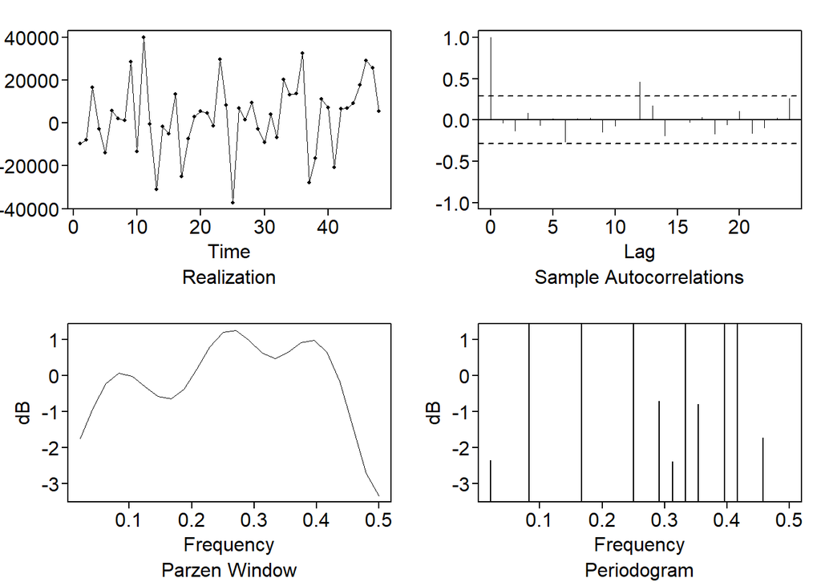

```
$xbar
[1] 2910.695

$autplt
 [1]  1.00000000 -0.03146441 -0.12717705  0.08315022 -0.06497396  0.01971589
 [7] -0.26286727  0.01691763  0.02226092 -0.14433216 -0.07280608  0.01089215
[13]  0.46441814  0.17594657 -0.18689026  0.00246225 -0.02287210  0.03103225
[19] -0.16547598 -0.05488838  0.10862428 -0.15734374 -0.09446281  0.02319014
[25]  0.25899927

$freq
 [1] 0.02083333 0.04166667 0.06250000 0.08333333 0.10416667 0.12500000
 [7] 0.14583333 0.16666667 0.18750000 0.20833333 0.22916667 0.25000000
[13] 0.27083333 0.29166667 0.31250000 0.33333333 0.35416667 0.37500000
[19] 0.39583333 0.41666667 0.43750000 0.45833333 0.47916667 0.50000000

$dbz
 [1] -1.74822448 -0.90959898 -0.22561612  0.06095811 -0.02174282 -0.30871443
 [7] -0.58526335 -0.65091196 -0.38039721  0.18030156  0.79625280  1.20032268
[13]  1.24919229  0.98098445  0.61957698  0.46958749  0.63950501  0.91577651
[19]  0.98879394  0.65131860 -0.17330279 -1.41495236 -2.72548132 -3.34106200

$db
 [1]  -2.3669091  -9.2791665 -11.3167640   6.1744655  -7.0270536 -11.9550446
 [7] -11.0266496   4.9130448 -11.0580255 -17.6903760  -5.8996531   7.1307293
[13] -16.4875416  -0.7218409  -2.3910297   2.4121647  -0.8005763 -10.6623234
[19]   4.2294604   3.4589441 -14.3986512  -1.7379150  -3.9530601 -10.4561888
```

```r
plotts.sample.wge(amazon_arma64_fit$res, lag.max = 24, arlimits = TRUE,periodogram=TRUE)
```

```r
ljung.wge(amazon_arma64_fit$res, K = 12, p = 6, q = 4)
```

```
Obs -0.03146441 -0.1271771 0.08315022 -0.06497396 0.01971589 -0.2628673 0.01691763 0.02226092 -0.1443322 -0.07280608 0.01089215 0.4644181
```

```
$test
[1] "Ljung-Box test"

$K
[1] 12

$chi.square
[1] 21.51352

$df
[1] 2

$pval
[1] 2.130095e-05
```

```r
ljung.wge(amazon_arma64_fit$res, K = 24, p = 6, q = 4)
```

```
Obs -0.03146441 -0.1271771 0.08315022 -0.06497396 0.01971589 -0.2628673 0.01691763 0.02226092 -0.1443322 -0.07280608 0.01089215 0.4644181 0.1759466 -0.1868903 0.00246225 -0.0228721 0.03103225 -0.165476 -0.05488838 0.1086243 -0.1573437 -0.09446281 0.02319014 0.2589993
```

```
$test
[1] "Ljung-Box test"

$K
[1] 24

$chi.square
[1] 39.45131

$df
[1] 14

$pval
[1] 0.0003105264
```

```r
shapiro.test(amazon_arma64_fit$res)
```

```
    Shapiro-Wilk normality test

data:  amazon_arma64_fit$res
W = 0.98407, p-value = 0.7527
```

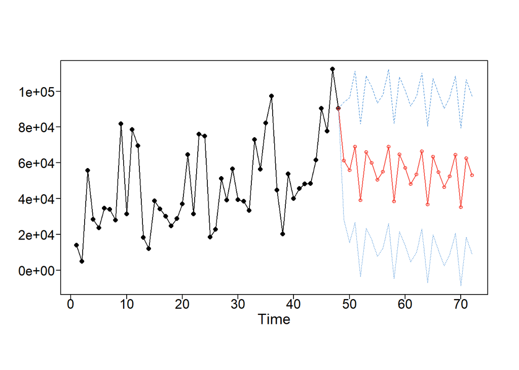

```
$f
 [1] 61325.69 55976.01 69062.77 39189.95 66038.21 59973.52 50480.27 55140.07
 [9] 69052.66 38557.82 64740.51 57162.17 48139.25 53492.62 66584.97 36719.47
[17] 63475.77 54980.75 46541.18 52432.29 64601.94 35340.83 62600.22 53185.40

$ll
 [1] 28671.348 15532.683 26688.276 -3445.029 23397.894 17248.067  7598.371
 [8] 12214.918 25942.307 -4704.498 21443.579 13739.663  4592.263  9930.463
[15] 22908.718 -7043.654 19700.604 11122.782  2605.079  8492.459 20583.369
[22] -8730.438 18525.887  9054.223

$ul
 [1]  93980.03  96419.34 111437.27  81824.93 108678.54 102698.98  93362.16
 [8]  98065.22 112163.02  81820.14 108037.43 100584.67  91686.24  97054.77
[15] 110261.23  80482.60 107250.94  98838.72  90477.27  96372.13 108620.51
[22]  79412.09 106674.55  97316.58

$resid
 [1]  -9542.5983  -7998.5283  16685.3966  -2916.9500 -13766.8794   5775.3241
 [7]   2083.8284   1143.0807  28631.2419 -13400.0417  39882.7332   -380.2219
[13] -31098.8305  -1504.7393  -5189.3581  13581.1872 -24943.1908  -7298.4361
[19]   2852.5686   5342.5434   4580.1986  -1347.0739  29619.4004   8334.9174
[25] -37165.0245   6994.4943   1626.8565   9507.2206  -2858.6641  -8927.2158
[31]   4149.7288  -6814.0388  20200.2886  13233.4559  13885.5023  32578.6097
[37] -27991.1924 -16495.7321  11297.6431   7269.9075 -20599.5246   6571.2394
[43]   6966.9496   9165.7905  17767.3514  29074.9813  25731.5330   5417.6510

$wnv
[1] 277578387

$xbar
[1] 47858.35

$se
 [1] 16660.68 20634.73 21620.04 21752.94 21755.67 21799.10 21878.92 21900.99
 [9] 21995.48 22073.02 22090.67 22154.75 22218.26 22226.00 22284.21 22328.54
[17] 22334.68 22376.93 22416.79 22418.69 22458.87 22485.75 22487.32 22516.32

$psi
 [1] 0.73072075 0.38728488 0.14410708 0.02066428 0.08255812 0.11206885
 [7] 0.05900071 0.12224231 0.11094718 0.05300334 0.10105818 0.10076277
[13] 0.03519901 0.09661739 0.08440287 0.03143802 0.08249227 0.08020426
[19] 0.01754887 0.08059040 0.06597782 0.01593234 0.06857170 0.06389255
```

```r
fore.arma.wge(amazon_ts, phi = amazon_arma64_fit$phi, theta = amazon_arma64_fit$theta,
 n.ahead = 24, limits = TRUE)
```

### 7b) Test for AR model

Test for p = 1, q = 0

```r
amazon_ar1_fit =  est.arma.wge(amazon_ts, p = 1, q = 0)
```

```
Coefficients of AR polynomial:
0.4108

                           AR Factor Table
Factor                 Roots                Abs Recip    System Freq
1-0.4108B              2.4342               0.4108       0.0000
```

Check against fitted AR1 model.

The realization here looks somewhat seasonal (more similar to the original dataset), with a period of 12. There appears to be an increasing trend especially near the end. The autocorrelation shows some decay, but there are some prominent spikes in the lag of 0, lag=12 and lag=24.

The Spectral frequency shows peaks near 0.08, and 0.33. This corresponds with a period of 12 and 3.

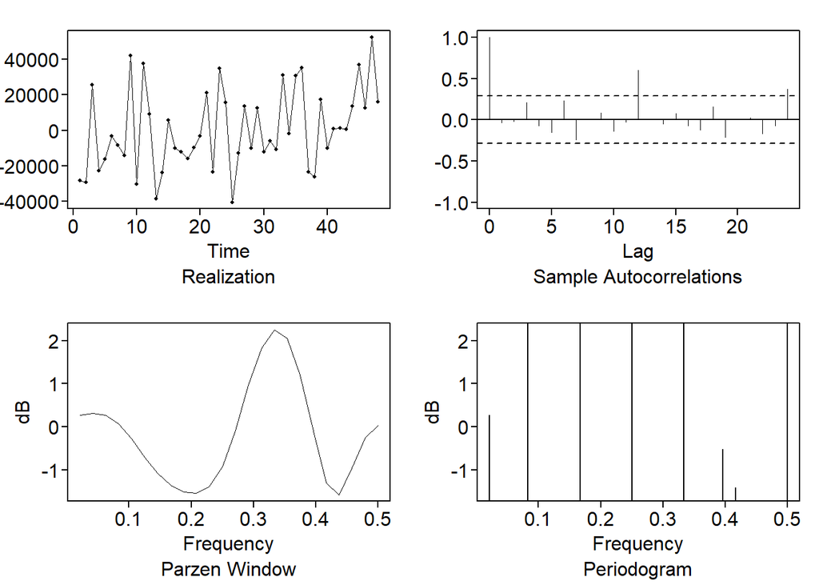

```
$xbar
[1] 483.9722

$autplt
 [1]  1.000000000 -0.036242570 -0.015686206  0.207869479 -0.069092770
 [6] -0.148815471  0.234057092 -0.237850206  0.011986724  0.082794139
[11] -0.139596827 -0.025715673  0.601679370  0.004012688 -0.046856799
[16]  0.079204339 -0.068579802 -0.119638355  0.159311220 -0.214175800
[21]  0.009517144  0.023958618 -0.168834605 -0.072221863  0.371583764

$freq
 [1] 0.02083333 0.04166667 0.06250000 0.08333333 0.10416667 0.12500000
 [7] 0.14583333 0.16666667 0.18750000 0.20833333 0.22916667 0.25000000
[13] 0.27083333 0.29166667 0.31250000 0.33333333 0.35416667 0.37500000
[19] 0.39583333 0.41666667 0.43750000 0.45833333 0.47916667 0.50000000

$dbz
 [1]  0.26632861  0.31184471  0.26923945  0.06638096 -0.28637576 -0.70257293
 [7] -1.07860482 -1.35434210 -1.51442123 -1.54576265 -1.38994208 -0.92323553
[13] -0.07949867  0.95740007  1.83180057  2.24684100  2.04613635  1.20677725
[19] -0.09746914 -1.29869779 -1.58110315 -0.96437989 -0.25121266  0.03182233

$db
 [1]   0.2645246  -9.8342980  -6.7874732   5.9215059  -5.5099251 -12.3876971
 [7] -14.7613324   4.6981894 -10.7345653 -19.3386366  -8.5567149   4.7239841
[13] -17.5499394  -4.8724568 -18.3629604   8.6609599  -6.2435932 -12.5012502
[19]  -0.5235575  -1.4210312 -17.8427914  -7.4209146 -10.0576186   6.6025974
```

```r
plotts.sample.wge(amazon_ar1_fit$res,lag.max = 24,arlimits = TRUE,periodogram = TRUE
)
```

```r
ljung.wge(amazon_ar1_fit$res, K = 12, p = 1, q = 0)
```

```
Obs -0.03624257 -0.01568621 0.2078695 -0.06909277 -0.1488155 0.2340571 -0.2378502 0.01198672 0.08279414 -0.1395968 -0.02571567 0.6016794
```

```
$test
[1] "Ljung-Box test"

$K
[1] 12

$chi.square
[1] 36.16156

$df
[1] 11

$pval
[1] 0.0001590786
```

```r
ljung.wge(amazon_ar1_fit$res, K = 24, p = 1, q = 0)
```

```
Obs -0.03624257 -0.01568621 0.2078695 -0.06909277 -0.1488155 0.2340571 -0.2378502 0.01198672 0.08279414 -0.1395968 -0.02571567 0.6016794 0.004012688 -0.0468568 0.07920434 -0.0685798 -0.1196384 0.1593112 -0.2141758 0.009517144 0.02395862 -0.1688346 -0.07222186 0.3715838
```

```
$test
[1] "Ljung-Box test"

$K
[1] 24

$chi.square
[1] 61.05962

$df
[1] 23

$pval
[1] 2.681146e-05
```

```r
shapiro.test(amazon_ar1_fit$res)
```

```
    Shapiro-Wilk normality test

data:  amazon_ar1_fit$res
W = 0.96891, p-value = 0.2297
```

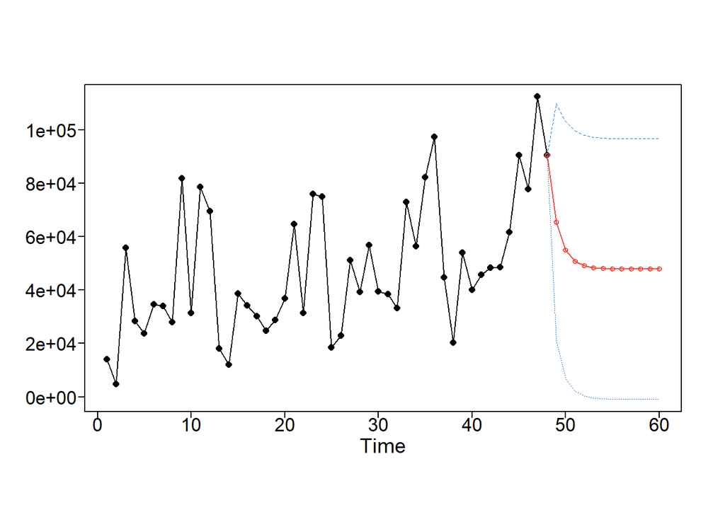

```
$f
 [1] 65365.72 55050.63 50813.04 49072.18 48357.01 48063.21 47942.51 47892.92
 [9] 47872.55 47864.19 47860.75 47859.34

$ll
 [1] 20900.1543  6979.0875  2159.2765   320.8395  -410.7799  -707.3579
 [7]  -828.5245  -878.1882  -898.5716  -906.9422  -910.3804  -911.7927

$ul
 [1] 109831.28 103122.17  99466.81  97823.52  97124.80  96833.77  96713.54
 [8]  96664.04  96643.68  96635.31  96631.88  96630.46

$resid
 [1] -28188.8258 -29116.2058  25517.3102 -22780.7747 -16173.3000  -3317.3811
 [7]  -8463.2353 -14233.6503  42114.2874 -30339.3710  37509.7582   9046.3607
[13] -38593.7177 -23712.2130   5618.9881  -9911.5451 -12113.6493 -15778.6905
[19]  -9619.2115  -3116.3293  21240.1002 -23329.4608  34873.5169  15511.4473
[25] -40432.9780 -12947.2633  13594.3801  -9976.8934  12369.7382 -12056.5190
[31]  -5955.2904 -10723.9030  31044.6844  -1686.0219  30799.0047  35274.1766
[37] -23440.8395 -26278.6325  17378.7506 -10231.6083    975.0245   1308.1120
[43]    405.1139  13423.5649  37019.5769  12422.2347  52170.2254  16131.8190

$wnv
[1] 514696777

$xbar
[1] 47858.35

$se
 [1] 22686.93 24526.75 24823.81 24873.59 24881.98 24883.40 24883.64 24883.68
 [9] 24883.68 24883.69 24883.69 24883.69

$psi
 [1] 4.108144e-01 1.687685e-01 6.933251e-02 2.848279e-02 1.170114e-02
 [6] 4.806997e-03 1.974783e-03 8.112694e-04 3.332811e-04 1.369167e-04
[11] 5.624734e-05 2.310722e-05
```

```r
 fore.arma.wge(amazon_ts,phi = amazon_ar1_fit$phi,theta = amazon_ar1_fit$theta,n.ahead = 12,limits = TRUE)
```

### 8) SLR line + noise tesing

Check against fitted SLR model.

The realization here looks somewhat seasonal (more similar to the original dataset), There appears to be an increasing trend especially near the end. The autocorrelation shows some decay, but there are some prominent spikes in the lag of 0, lag=12 and lag=24.

The Spectral frequency shows peaks near 0.08, and 0.33. This corresponds with a period of 12 and 3.

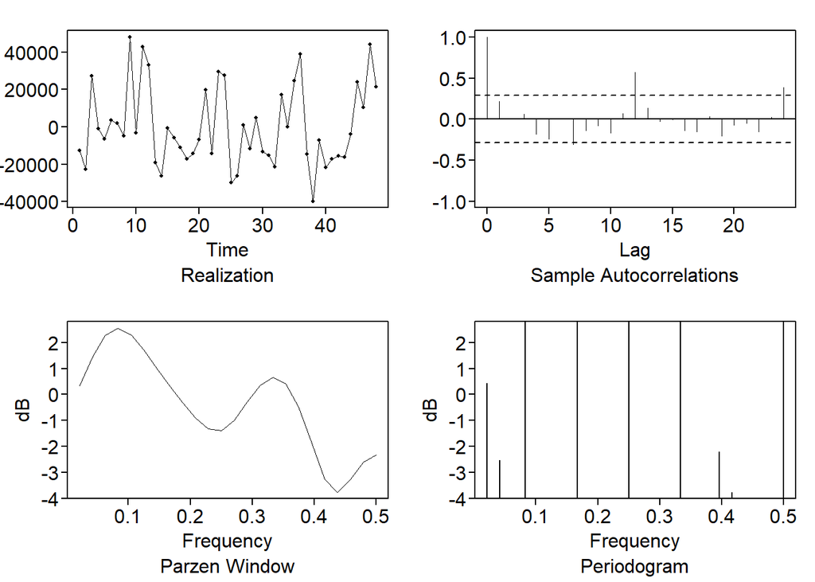

```
$xbar
[1] -1.206949e-11

$autplt
 [1]  1.000000000  0.220401853  0.014476798  0.065423243 -0.183970952
 [6] -0.240898379  0.002113099 -0.304998256 -0.137938686 -0.076313906
[11] -0.164925781  0.067803941  0.572012960  0.134756985 -0.027830084
[16] -0.004323294 -0.133916799 -0.148626491  0.034514693 -0.207087443
[21] -0.066991365 -0.050424072 -0.148901889  0.023184403  0.390220727

$freq
 [1] 0.02083333 0.04166667 0.06250000 0.08333333 0.10416667 0.12500000
 [7] 0.14583333 0.16666667 0.18750000 0.20833333 0.22916667 0.25000000
[13] 0.27083333 0.29166667 0.31250000 0.33333333 0.35416667 0.37500000
[19] 0.39583333 0.41666667 0.43750000 0.45833333 0.47916667 0.50000000

$dbz
 [1]  0.3283723  1.4411217  2.2742312  2.5504081  2.3064474  1.7181729
 [7]  1.0051653  0.3164302 -0.3208525 -0.9010026 -1.3177937 -1.3803540
[13] -0.9866203 -0.2906879  0.3677759  0.6685003  0.4107384 -0.4754224
[19] -1.8697235 -3.2568012 -3.7652696 -3.2724230 -2.5942014 -2.3170573

$db
 [1]   0.427815  -2.529016 -18.844225   8.353064  -7.070861  -6.179978
 [7]  -8.786351   5.957414  -8.177094 -14.828659  -6.913201   4.090333
[13] -18.764663  -5.592955 -19.464613   6.972821  -8.642804 -12.566383
[19]  -2.209783  -3.765017 -23.283333  -9.871806 -11.759003   4.303565
```

```r
amazon_reg = slr.wge(amazon_ts)

t = 1:length(amazon_ts)

amazon_zhat = amazon_ts - amazon_reg$b0hat - amazon_reg$b1hat * t

plotts.sample.wge(  amazon_zhat, lag.max = 24, arlimits = TRUE,  periodogram = TRUE)
```

```r
aic.wge(amazon_zhat, p = 0:10, q = 0:6) #picks p = 5 and q = 1
```

```
$type
[1] "aic"

$value
[1] 19.8233

$p
[1] 5

$q
[1] 1

$phi
[1] -0.56160995  0.15675655  0.05307411 -0.09182706 -0.42624206

$theta
[1] -0.9893882

$xbar
[1] -1.206949e-11

$vara
[1] 303725262
```

```r
aic.wge(amazon_zhat, p = 0:10, q = 0:6, type = "bic") #picks p = 0 and q = 0
```

```
$type
[1] "bic"

$value
[1] 20.02411

$p
[1] 0

$q
[1] 0

$phi
[1] 0

$theta
[1] 0

$xbar
[1] -1.206949e-11

$vara
[1] 458492975
```

### 8b) Line + ARMA fit testing

Try line + ARMA fit?

```r
amazon_line_arma51_fit = est.arma.wge(amazon_zhat, p = 5, q = 1)
```

```
Coefficients of AR polynomial:
-0.5616 0.1568 0.0531 -0.0918 -0.4262

                           AR Factor Table
Factor                 Roots                Abs Recip    System Freq
1+0.9999B             -1.0001               0.9999       0.5000
1+0.8168B+0.6766B^2   -0.6036+-1.0553i      0.8225       0.3327
1-1.2551B+0.6301B^2    0.9960+-0.7714i      0.7938       0.1049




Coefficients of MA polynomial:
-0.9894

                              MA FACTOR TABLE
Factor                 Roots                Abs Recip    System Freq
1+0.9894B             -1.0107               0.9894       0.5000
```

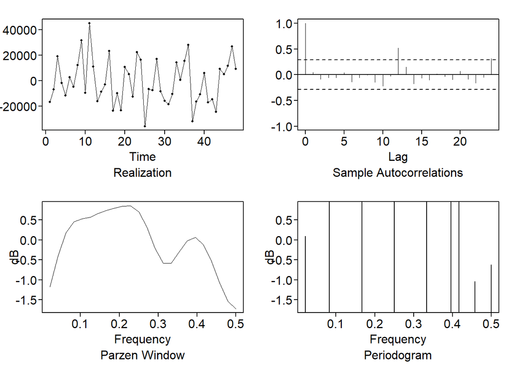

```
$xbar
[1] -455.1726

$autplt
 [1]  1.000000000  0.050106849 -0.084456888 -0.054688799 -0.057140891
 [6]  0.042390443 -0.136503420 -0.055314186 -0.001942458 -0.144416513
[11] -0.220187729 -0.027478857  0.523901176  0.147802644 -0.173472932
[16] -0.066118316 -0.100921699  0.015060726 -0.036240772 -0.094035294
[21]  0.066386102 -0.087489526 -0.158923927 -0.048845493  0.314606871

$freq
 [1] 0.02083333 0.04166667 0.06250000 0.08333333 0.10416667 0.12500000
 [7] 0.14583333 0.16666667 0.18750000 0.20833333 0.22916667 0.25000000
[13] 0.27083333 0.29166667 0.31250000 0.33333333 0.35416667 0.37500000
[19] 0.39583333 0.41666667 0.43750000 0.45833333 0.47916667 0.50000000

$dbz
 [1] -1.16985480 -0.41706506  0.17973378  0.45464186  0.52490124  0.57137807
 [7]  0.65933786  0.74227654  0.79519076  0.84121235  0.84941710  0.70308986
[13]  0.32023302 -0.20391816 -0.58270100 -0.58241339 -0.30039591 -0.02057189
[19]  0.05920104 -0.12276434 -0.53478393 -1.06739016 -1.53346432 -1.72189150

$db
 [1]   0.09279916  -4.13046167 -14.87863744   5.73591197  -7.39085477
 [6] -15.38331012  -7.60039745   6.46685003  -7.44908193 -11.14951431
[11]  -3.40852128   6.60795371 -14.50055185  -4.52563836 -18.57874592
[16]   4.29473147 -10.06778504 -12.27358626   2.28036187   2.96838173
[21] -14.58004490  -1.04387821  -2.75831994  -0.62644799
```

```r
plotts.sample.wge(amazon_line_arma51_fit$res,lag.max = 24,arlimits = TRUE,periodogram = TRUE)
```

```r
ljung.wge(amazon_line_arma51_fit$res, K = 12, p = 5, q = 1)
```

```
Obs 0.05010685 -0.08445689 -0.0546888 -0.05714089 0.04239044 -0.1365034 -0.05531419 -0.001942458 -0.1444165 -0.2201877 -0.02747886 0.5239012
```

```
$test
[1] "Ljung-Box test"

$K
[1] 12

$chi.square
[1] 24.875

$df
[1] 6

$pval
[1] 0.0003601368
```

```r
ljung.wge(amazon_line_arma51_fit$res, K = 24, p = 5, q = 1)
```

```
Obs 0.05010685 -0.08445689 -0.0546888 -0.05714089 0.04239044 -0.1365034 -0.05531419 -0.001942458 -0.1444165 -0.2201877 -0.02747886 0.5239012 0.1478026 -0.1734729 -0.06611832 -0.1009217 0.01506073 -0.03624077 -0.09403529 0.0663861 -0.08748953 -0.1589239 -0.04884549 0.3146069
```

```
$test
[1] "Ljung-Box test"

$K
[1] 24

$chi.square
[1] 43.94979

$df
[1] 18

$pval
[1] 0.0005865091
```

```r
shapiro.test(amazon_line_arma51_fit$res)
```

```
    Shapiro-Wilk normality test

data:  amazon_line_arma51_fit$res
W = 0.98086, p-value = 0.6149
```

```r
ljung.wge(amazon_zhat, K = 12, p = 0, q = 0)
```

```
Obs 0.2204019 0.0144768 0.06542324 -0.183971 -0.2408984 0.002113099 -0.3049983 -0.1379387 -0.07631391 -0.1649258 0.06780394 0.572013
```

```
$test
[1] "Ljung-Box test"

$K
[1] 12

$chi.square
[1] 38.57981

$df
[1] 12

$pval
[1] 0.0001233886
```

```r
#ljung.wge(amazon_zhat, K = 24, p = 0, q = 0)
```

```r
shapiro.test(amazon_zhat)
```

```
    Shapiro-Wilk normality test

data:  amazon_zhat
W = 0.93759, p-value = 0.01313
```

## Model Comparisons

```r
model_results = data.frame(
  model = c("AIC ARMA(6,4)","BIC AR(1)","Line + AIC ARMA(5,1)", "Line + noise"),
  ljung_k12_p = c(
    ljung.wge(amazon_arma64_fit$res, K = 12, p = 6, q = 4)$pval,
    ljung.wge(amazon_ar1_fit$res, K = 12, p = 1, q = 0)$pval,
    ljung.wge(amazon_line_arma51_fit$res, K = 12, p = 5, q = 1)$pval,
    ljung.wge(amazon_zhat, K = 12, p = 0, q = 0)$pval
  ),
  ljung_k24_p = c(
    ljung.wge(amazon_arma64_fit$res, K = 24, p = 6, q = 4)$pval,
    ljung.wge(amazon_ar1_fit$res, K = 24, p = 1, q = 0)$pval,
    ljung.wge(amazon_line_arma51_fit$res, K = 24, p = 5, q = 1)$pval,
    ljung.wge(amazon_zhat, K = 24, p = 0, q = 0)$pval
  ),
  shapiro_p = c(
    shapiro.test(amazon_arma64_fit$res)$p.value,
    shapiro.test(amazon_ar1_fit$res)$p.value,
    shapiro.test(amazon_line_arma51_fit$res)$p.value,
    shapiro.test(amazon_zhat)$p.value
  )
)
```

```
Obs -0.03146441 -0.1271771 0.08315022 -0.06497396 0.01971589 -0.2628673 0.01691763 0.02226092 -0.1443322 -0.07280608 0.01089215 0.4644181
Obs -0.03624257 -0.01568621 0.2078695 -0.06909277 -0.1488155 0.2340571 -0.2378502 0.01198672 0.08279414 -0.1395968 -0.02571567 0.6016794
Obs 0.05010685 -0.08445689 -0.0546888 -0.05714089 0.04239044 -0.1365034 -0.05531419 -0.001942458 -0.1444165 -0.2201877 -0.02747886 0.5239012
Obs 0.2204019 0.0144768 0.06542324 -0.183971 -0.2408984 0.002113099 -0.3049983 -0.1379387 -0.07631391 -0.1649258 0.06780394 0.572013
Obs -0.03146441 -0.1271771 0.08315022 -0.06497396 0.01971589 -0.2628673 0.01691763 0.02226092 -0.1443322 -0.07280608 0.01089215 0.4644181 0.1759466 -0.1868903 0.00246225 -0.0228721 0.03103225 -0.165476 -0.05488838 0.1086243 -0.1573437 -0.09446281 0.02319014 0.2589993
Obs -0.03624257 -0.01568621 0.2078695 -0.06909277 -0.1488155 0.2340571 -0.2378502 0.01198672 0.08279414 -0.1395968 -0.02571567 0.6016794 0.004012688 -0.0468568 0.07920434 -0.0685798 -0.1196384 0.1593112 -0.2141758 0.009517144 0.02395862 -0.1688346 -0.07222186 0.3715838
Obs 0.05010685 -0.08445689 -0.0546888 -0.05714089 0.04239044 -0.1365034 -0.05531419 -0.001942458 -0.1444165 -0.2201877 -0.02747886 0.5239012 0.1478026 -0.1734729 -0.06611832 -0.1009217 0.01506073 -0.03624077 -0.09403529 0.0663861 -0.08748953 -0.1589239 -0.04884549 0.3146069
Obs 0.2204019 0.0144768 0.06542324 -0.183971 -0.2408984 0.002113099 -0.3049983 -0.1379387 -0.07631391 -0.1649258 0.06780394 0.572013 0.134757 -0.02783008 -0.004323294 -0.1339168 -0.1486265 0.03451469 -0.2070874 -0.06699137 -0.05042407 -0.1489019 0.0231844 0.3902207
```

```r
model_results
```

```
                 model  ljung_k12_p  ljung_k24_p  shapiro_p
1        AIC ARMA(6,4) 2.130095e-05 3.105264e-04 0.75271412
2            BIC AR(1) 1.590786e-04 2.681146e-05 0.22969588
3 Line + AIC ARMA(5,1) 3.601368e-04 5.865091e-04 0.61490579
4         Line + noise 1.233886e-04 1.432599e-05 0.01312508
```

This forecast is exploratory because none of the candidate models fully passed Ljung-Box diagnostics.

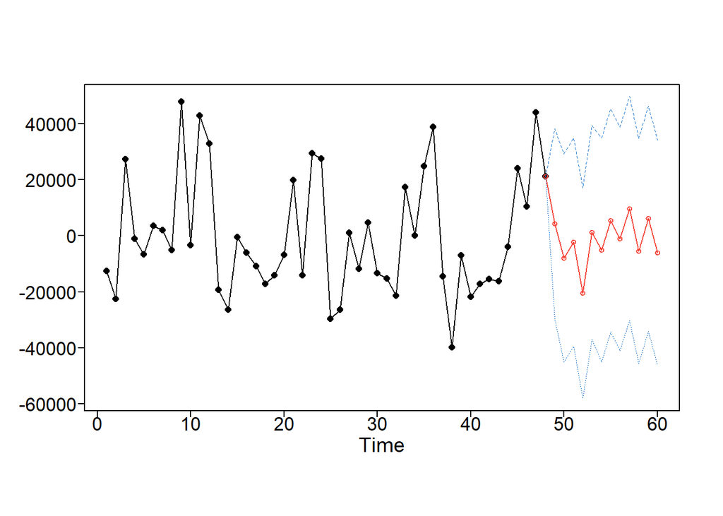

```r
noise_forecast = fore.arma.wge(amazon_zhat,phi = amazon_line_arma51_fit$phi,
  theta = amazon_line_arma51_fit$theta,n.ahead = 12,limits = TRUE)
```

```r
future_t = (length(amazon_ts) + 1):(length(amazon_ts) + 12)
future_line = amazon_reg$b0hat + amazon_reg$b1hat * future_t

final_forecast = future_line + noise_forecast$f

final_forecast
```

```
 [1] 74299.32 63035.79 69599.91 52270.27 74927.11 69457.19 81052.89 75372.76
 [9] 87089.94 72773.14 85309.24 73919.14
```

## Explored but inconclusive

### A1) Attempted Smoothing that did not yield much results

```r
amazon_ts_5=ma.smooth.wge(amazon_ts,order= 5, plot= FALSE)
```

```
3 25278.29 t.start,x.sm
```

[figure not shown]

```r
plot(amazon_ts,xlab='Time Stamp',ylab='Amazon monthly sales',main='Amazon Sales for Regular vs 5th order Smooth')
lines(amazon_ts_5$smooth,col = "red", lty = 5)
legend("topleft",
       legend = c("Regular", "5th Order Smooth"),
       col = c("black", "red"),
       lty = 1,
       lwd = c(1, 2))
```

### A2) Try some decomposition

Additive Decomposition

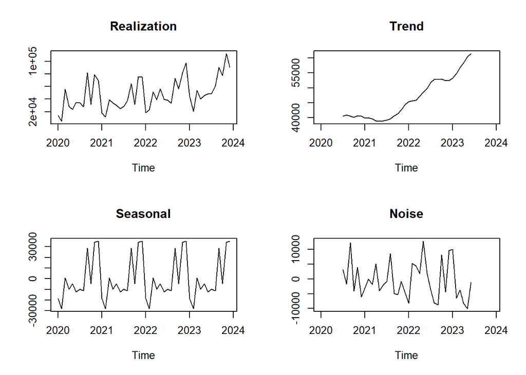

```r
new_plot = decompose(amazon_ts,type= 'additive')


par(mfrow = c(2, 2))
plot(new_plot$x, main = "Realization", ylab = "")
plot(new_plot$trend, main = "Trend", ylab = "")
plot(new_plot$seasonal, main = "Seasonal", ylab = "")
plot(new_plot$random, main = "Noise", ylab = "")
```

Multiplicative Decomposition

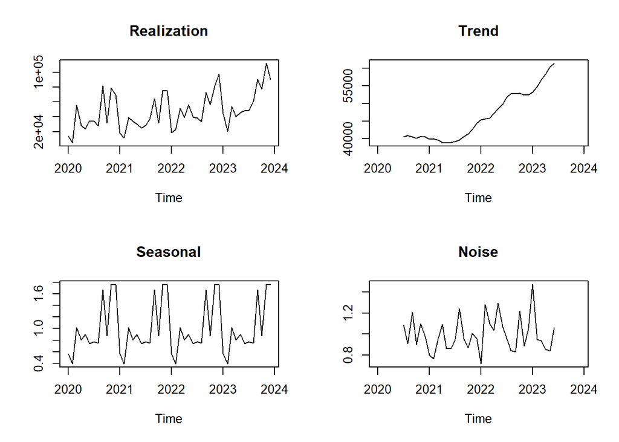

```r
new_plot = decompose(amazon_ts,type= 'multiplicative')


par(mfrow = c(2, 2))
plot(new_plot$x, main = "Realization", ylab = "")
plot(new_plot$trend, main = "Trend", ylab = "")
plot(new_plot$seasonal, main = "Seasonal", ylab = "")
plot(new_plot$random, main = "Noise", ylab = "")
```